# Lab 5. Modeling and Analysis for Point Pattern

Spatial Big Data Analysis with GIS (jaehongjeong@hanyang.ac.kr)

Korean Statistical Society, Winter School, February 24, 2023

This document is based on “Applied Spatial Data Analysis with R” by Bivand, Pebesma, and Gomez-Rubio.

```r
# Required packages
library(spatstat)
library(spatstat.explore)
library(maptools)
```

# 1 Modeling and Analysis for Point Pattern using ${\tt spatstat}$

## 1.1 Inspecting data

We will use one of the standard pattern datasets that is installed with the package. The `Swedish Pines’ dataset represent the positions of 71 trees in a forest plot 9.6 by 10.0 meters.

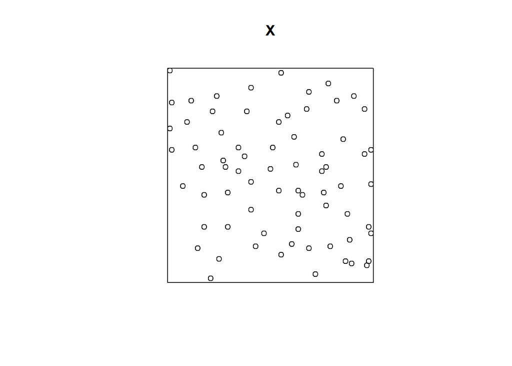

```r
#library(spatstat)
#library(spatstat.explore)
#library(maptools)
data(swedishpines)
X <- swedishpines
plot(X)
```

```r
# Study the intensity (density of points) in this point pattern.
summary(X)
```

```
## Planar point pattern:  71 points
## Average intensity 0.007395833 points per square unit (one unit = 0.1 metres)
##
## Coordinates are integers
## i.e. rounded to the nearest unit (one unit = 0.1 metres)
##
## Window: rectangle = [0, 96] x [0, 100] units
## Window area = 9600 square units
## Unit of length: 0.1 metres
```

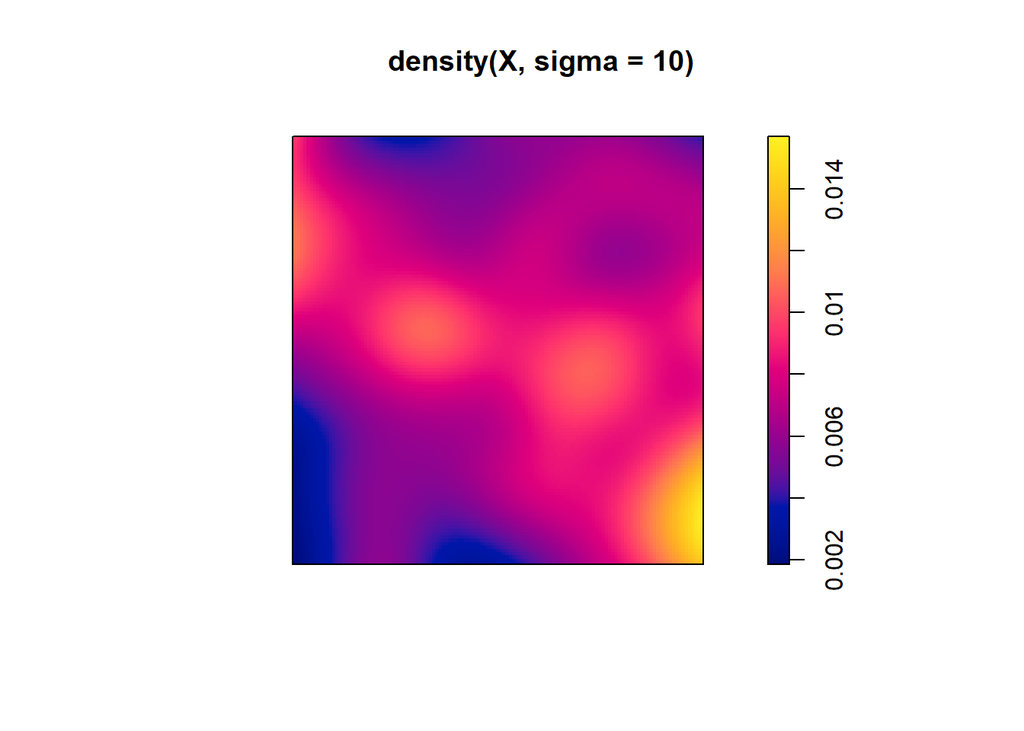

```r
plot(density(X, sigma=10)) # 10 is the chosen value for the standard deviation of the Gaussian smoothing kernel.
```

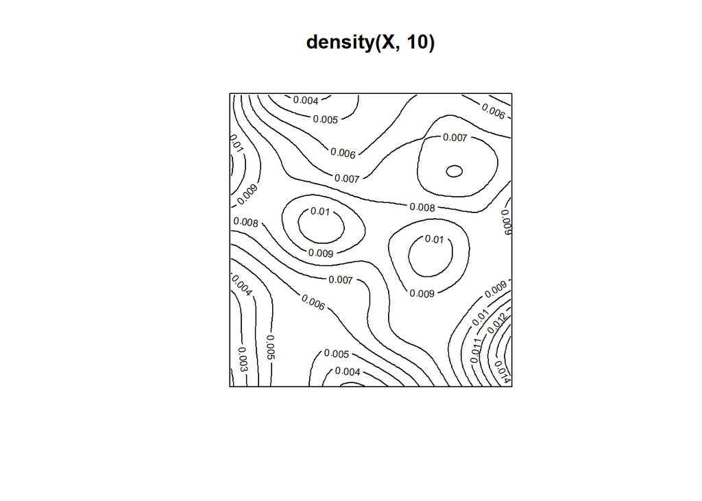

```r
contour(density(X, 10), axes=FALSE)
```

The contours are labeled in density units of ``trees per square decimeter”.

## 1.2 Exploratory data analysis

The ${\tt spatstat}$ is designed to support all the standard types of EDA for point patterns. One example is ${\it quadrat counting}$. The study region is divided into rectangles of equal size, and the number of points in each rectangle is counted.

```r
Q <- quadratcount(X, nx=4, ny=3)
Q
```

```
##              x
## y             [0,24) [24,48) [48,72) [72,96]
##   [66.7,100]       7       3       6       5
##   [33.3,66.7)      5       9       7       7
##   [0,33.3)         4       3       6       9
```

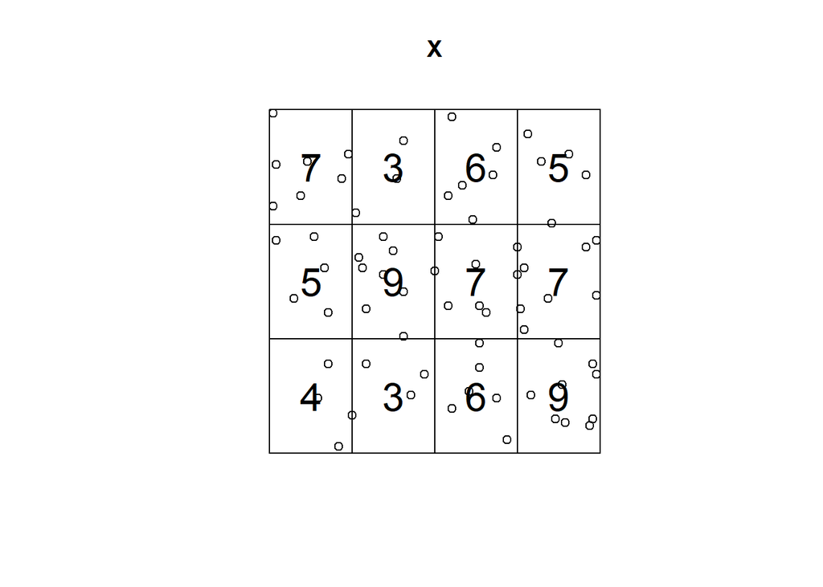

```r
plot(X)
plot(Q, add=TRUE, cex=2)
```

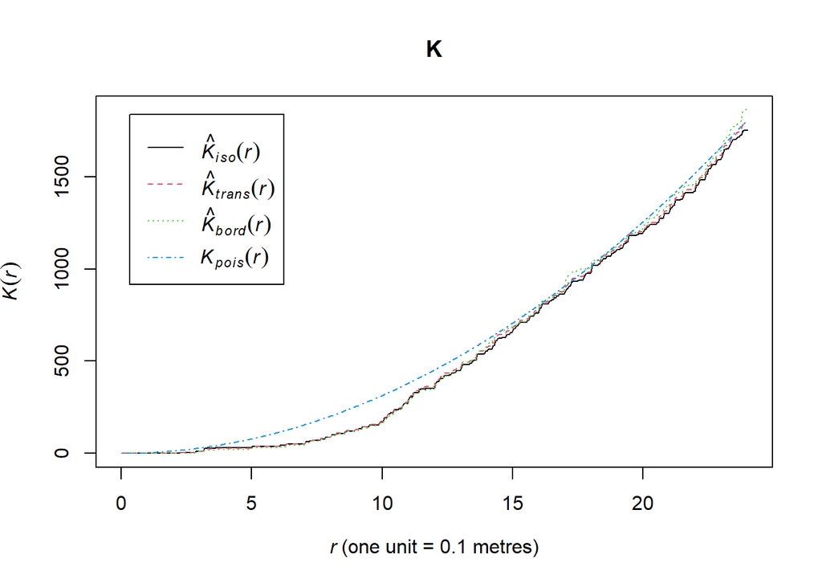

```r
K <- Kest(X)
plot(K)
```

Another example is ${\it Ripley's\ K\ function}$.

## 1.3 Multitype point patterns

A marked point pattern in which the marks are a categorical variable is usually called a ${\it multitype}$ point pattern. The `types’ are the different values or levels of the mark variable. Here is the famous Lansing Woods dataset recording the positions of 2251 trees of 6 different species (hickories, maples, red oaks, white oaks, black oaks and miscellaneous trees).

```r
data(lansing)
lansing
```

```
## Marked planar point pattern: 2251 points
## Multitype, with levels = blackoak, hickory, maple, misc, redoak, whiteoak
## window: rectangle = [0, 1] x [0, 1] units (one unit = 924 feet)
```

```r
summary(lansing)
```

```
## Marked planar point pattern:  2251 points
## Average intensity 2251 points per square unit (one unit = 924 feet)
##
## *Pattern contains duplicated points*
##
## Coordinates are given to 3 decimal places
## i.e. rounded to the nearest multiple of 0.001 units (one unit = 924 feet)
##
## Multitype:
##          frequency proportion intensity
## blackoak       135 0.05997335       135
## hickory        703 0.31230560       703
## maple          514 0.22834300       514
## misc           105 0.04664594       105
## redoak         346 0.15370950       346
## whiteoak       448 0.19902270       448
##
## Window: rectangle = [0, 1] x [0, 1] units
## Window area = 1 square unit
## Unit of length: 924 feet
```

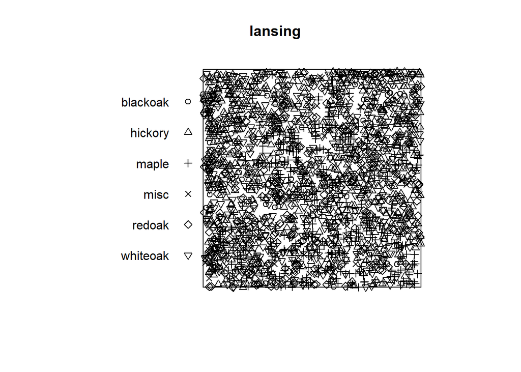

```r
plot(lansing)
```

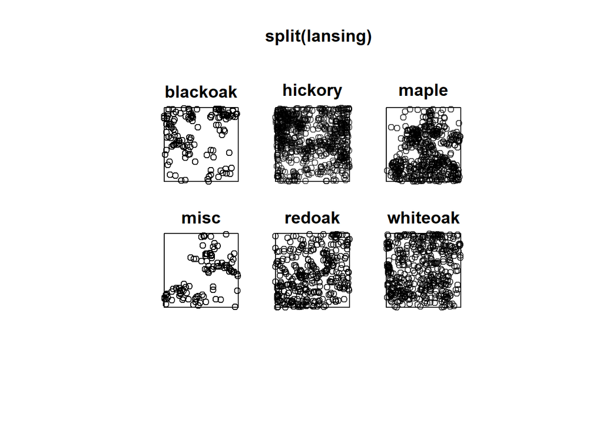

```r
plot(split(lansing))
```

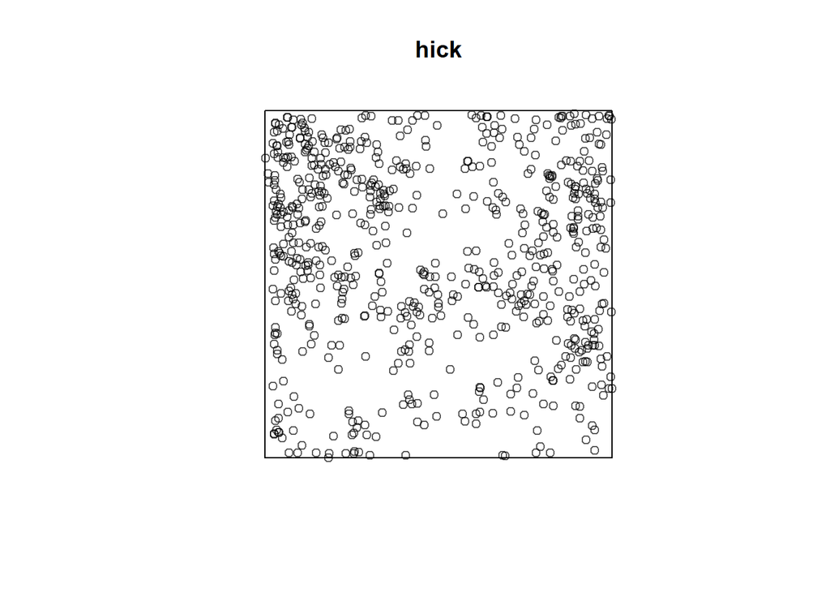

```r
hick <- split(lansing)$hickory
plot(hick)
```

## 1.4 Classes in ${\tt spatstat}$

To handle point pattern datasets and related data, the ${\tt spatstat}$ package defines the following classes of objects:

- ${\tt ppp}$: planar point pattern
- ${\tt owin}$: spatial region (observation window)
- ${\tt im}$: pixel image
- ${\tt psp}$: pattern of line segments

```r
#methods(plot)
methods(class = "ppp")
```

```
##   [1] [                        [<-                      affine
##   [4] anyDuplicated            as.data.frame            as.im
##   [7] as.layered               as.owin                  as.ppp
##  [10] auc                      berman.test              boundingbox
##  [13] boundingcentre           boundingcircle           boundingradius
##  [16] bw.relrisk               by                       cdf.test
##  [19] circumradius             closepairs               closing
##  [22] coerce                   connected                coords
##  [25] coords<-                 crossdist                crosspairs
##  [28] cut                      density                  densityAdaptiveKernel
##  [31] densityfun               densityHeat              densityVoronoi
##  [34] dilation                 distfun                  distmap
##  [37] domain                   duplicated               edit
##  [40] envelope                 erosion                  fardist
##  [43] flipxy                   Frame<-                  has.close
```

[output cut: 26 more lines]

# 2 Manipulating point pattern - example

We will use one of the standard point pattern datasets that is installed with the package. The NZ trees dataset represent the positions of 86 trees in a forest plot 153 by 95 feet.

```r
data(nztrees)
nztrees
```

```
## Planar point pattern: 86 points
## window: rectangle = [0, 153] x [0, 95] feet
```

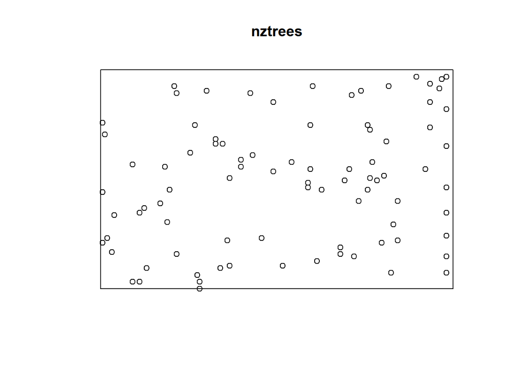

```r
plot(nztrees)
```

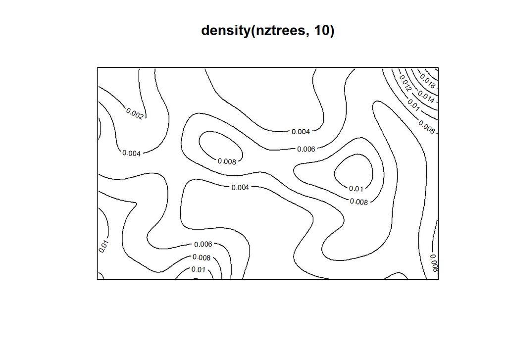

```r
contour(density(nztrees, 10), axes=FALSE)
```

The density surface has a steep slope at the top right-hand corner of the study region. Looking at the plot of the point pattern itself, we can see a cluster of trees at the top right.

You may also notice a line of trees at the right-hand edge of the study region. It looks as though the study region may have included some trees that were planted as a boundary or avenue. This sticks out like a sore thumb if we plot the x coordinates of the trees:

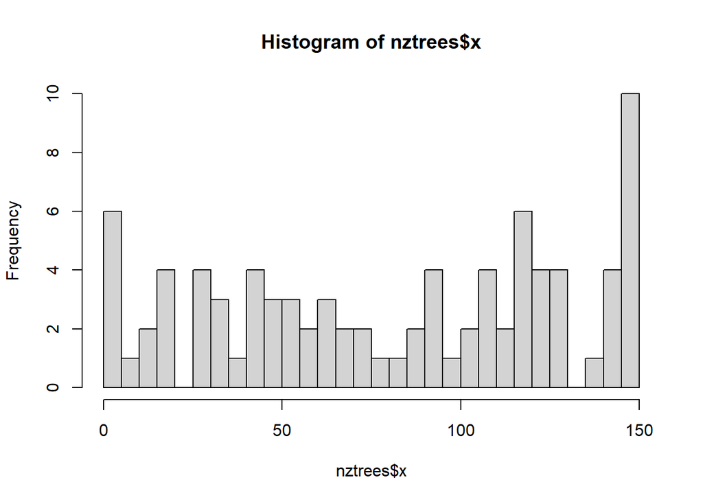

```r
hist(nztrees$x, nclass=25)
```

We might want to exclude the right-hand boundary from the study region, to focus on the pattern of the remaining trees. Let’s say we decide to trim a 5-foot margin off the right-hand side.

First we create the new, trimmed study region:

```r
chopped <- owin(c(0, 148), c(0, 95))
#or
win <- nztrees$window
chopped <- trim.rectangle(win, xmargin=c(0, 5), ymargin=0)
chopped
```

```
## window: rectangle = [0, 148] x [0, 95] feet
```

```r
nzchop <- nztrees[chopped]
```

We can now study the `chopped’ point pattern.

```r
summary(nzchop)
```

```
## Planar point pattern:  78 points
## Average intensity 0.005547653 points per square foot
##
## Coordinates are integers
## i.e. rounded to the nearest foot
##
## Window: rectangle = [0, 148] x [0, 95] feet
## Window area = 14060 square feet
## Unit of length: 1 foot
```

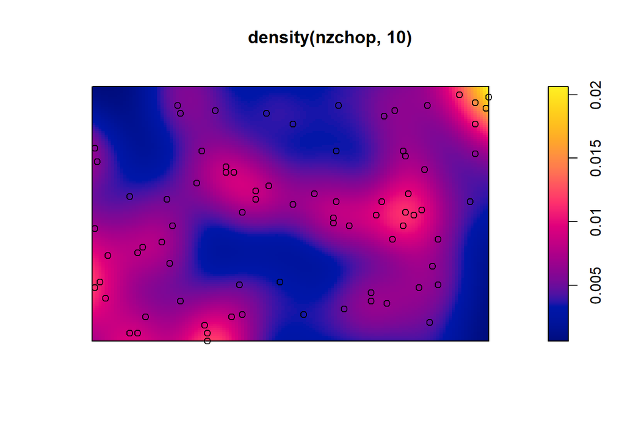

```r
plot(density(nzchop, 10))
plot(nzchop, add=TRUE)
```

# 3 Tests of complete spatial randomness

In classical literature, the homogeneous Poisson process (Complete Spatial Randomness, CSR) is usually taken as the appropriate `null’ model for a point pattern. Our basic task in analyzing a point pattern is to find evidence against CSR.

## 3.1 Quadrat counting tests for CSR

```r
#quadrat.test(nzchop, nx=3, ny=2)
M <- quadrat.test(nzchop, nx=3, ny=2)
M
```

```
##
##  Chi-squared test of CSR using quadrat counts
##
## data:  nzchop
## X2 = 5.0769, df = 5, p-value = 0.8131
## alternative hypothesis: two.sided
##
## Quadrats: 3 by 2 grid of tiles
```

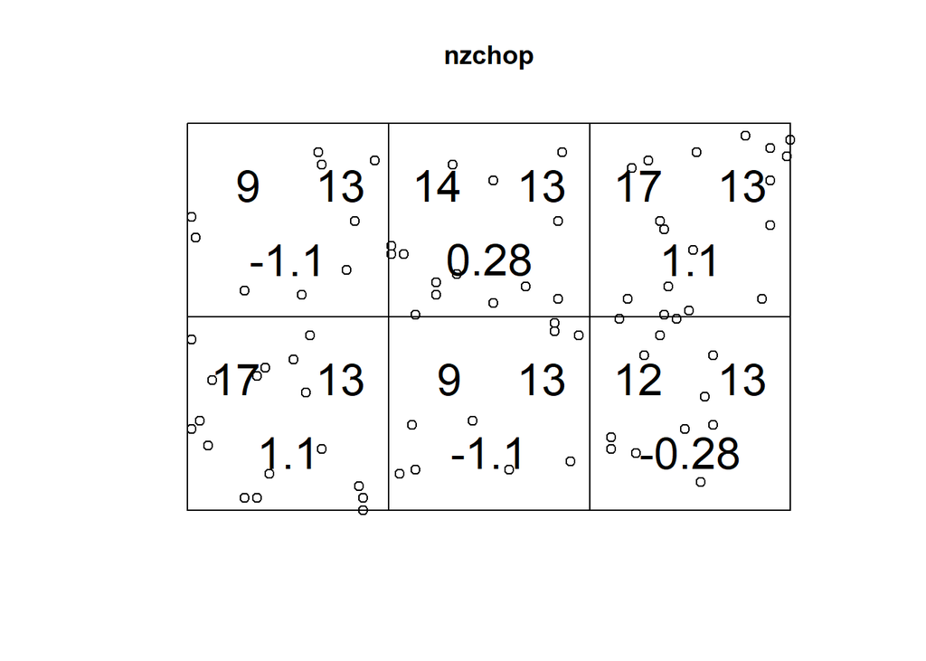

```r
plot(nzchop)
plot(M, add=TRUE, cex=2)
```

```r
# The null hypothesis: data pattern is a realization of CSR
M$p.value
```

```
## [1] 0.8131295
```

Typically a more powerful test of CSR is the Kolmogorov-Smirnov test in which we compare the observed and expected distributions of the values of some function $T$.

# 4 Maximum likelihood for Poisson process

The ${\it inhomogeneous}$ Poisson process can be simulated using ${\tt rpoispp}$.

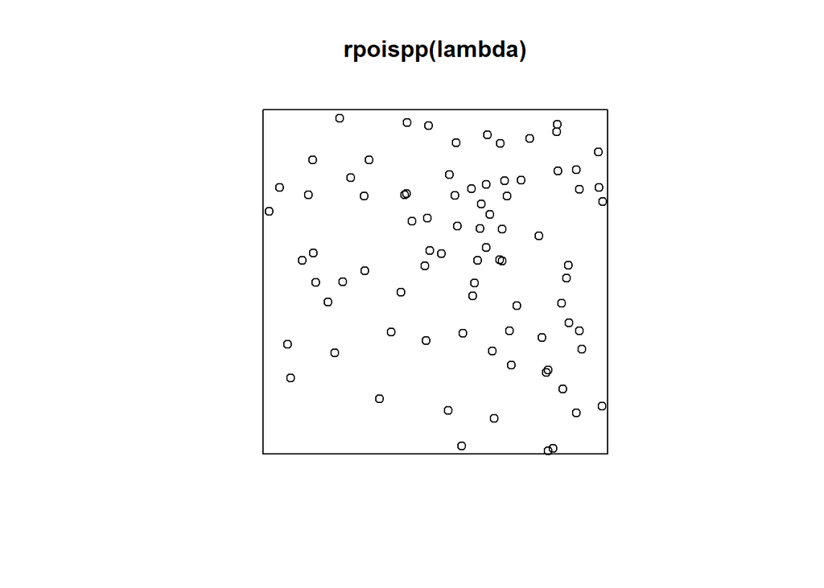

```r
lambda <- function(x, y) {
 100 * (x + y)
}
plot(rpoispp(lambda))
```

## 4.1 Model-fitting function

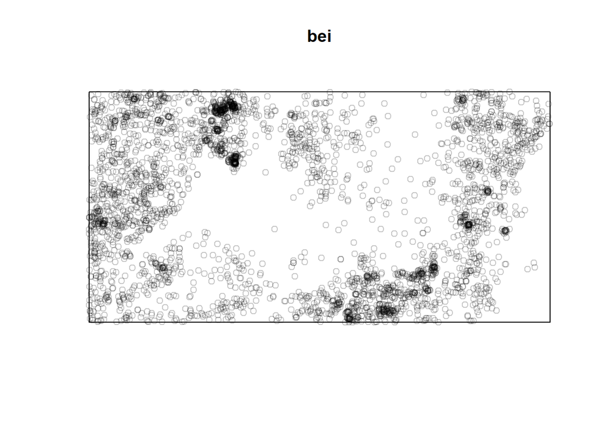

```r
data(bei)
plot(bei)
```

```r
# fit the homogeneous Poisson model
ppm(bei, ~1)
```

```
## Stationary Poisson process
## Intensity: 0.007208
##              Estimate       S.E.   CI95.lo   CI95.hi Ztest      Zval
## log(lambda) -4.932564 0.01665742 -4.965212 -4.899916   *** -296.1182
```

```r
# fit the inhomogeneous Poisson model with an intensity that is log-linear in the cartesian coordinates
ppm(bei, ~x + y)
```

```
## Nonstationary Poisson process
##
## Log intensity:  ~x + y
##
## Fitted trend coefficients:
##   (Intercept)             x             y
## -4.7245290274 -0.0008031288  0.0006496090
##
##                  Estimate         S.E.       CI95.lo       CI95.hi Ztest
## (Intercept) -4.7245290274 4.305915e-02 -4.8089234185 -4.6401346364   ***
## x           -0.0008031288 5.863311e-05 -0.0009180476 -0.0006882100   ***
## y            0.0006496090 1.157132e-04  0.0004228153  0.0008764027   ***
##                    Zval
## (Intercept) -109.721827
## x            -13.697530
## y              5.613957
```

```r
# fit the inhomogeneous Poisson model with an intensity that is log-quadratic in cartesian coordinates
ppm(bei, ~polynom(x, y, 2))
```

```
## Nonstationary Poisson process
##
## Log intensity:  ~x + y + I(x^2) + I(x * y) + I(y^2)
##
## Fitted trend coefficients:
##   (Intercept)             x             y        I(x^2)      I(x * y)
## -4.275762e+00 -1.609187e-03 -4.895166e-03  1.625968e-06 -2.836387e-06
##        I(y^2)
##  1.331331e-05
##
##                  Estimate         S.E.       CI95.lo       CI95.hi Ztest
## (Intercept) -4.275762e+00 7.811138e-02 -4.428857e+00 -4.122666e+00   ***
## x           -1.609187e-03 2.440907e-04 -2.087596e-03 -1.130778e-03   ***
## y           -4.895166e-03 4.838993e-04 -5.843591e-03 -3.946741e-03   ***
## I(x^2)       1.625968e-06 2.197200e-07  1.195325e-06  2.056611e-06   ***
## I(x * y)    -2.836387e-06 3.511163e-07 -3.524562e-06 -2.148212e-06   ***
## I(y^2)       1.331331e-05 8.487506e-07  1.164979e-05  1.497683e-05   ***
##                   Zval
## (Intercept) -54.739290
## x            -6.592577
## y           -10.116084
## I(x^2)        7.400185
## I(x * y)     -8.078197
## I(y^2)       15.685769
```

It is possible to fit an inhomogeneous Poisson process model with an intensity function that depends on an observed covariate.

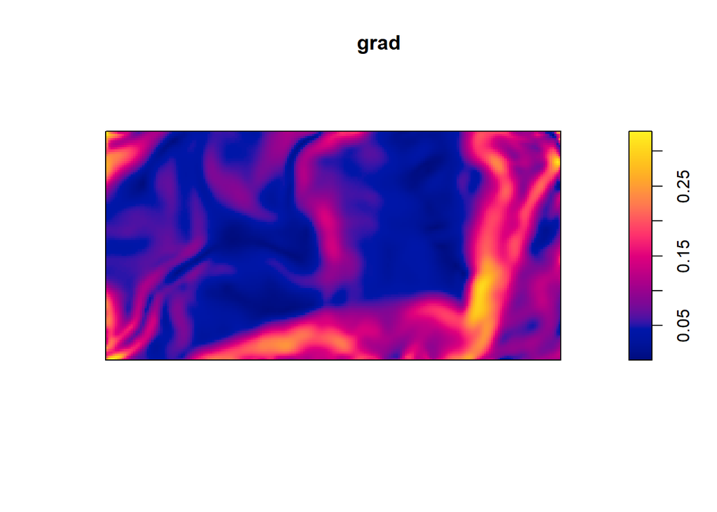

```r
grad <- bei.extra$grad
plot(grad)
```

To fit the inhomogeneous Poisson model with intensity which is a loglinear function of slope, i.e., $\lambda(u)=\exp(\beta_{0}+\beta_{1}Z(u))$ where $\beta_{0},\beta_{1}$ are parameters and $Z(u)$ is the slope at location $u$.

```r
ppm(bei, ~slope, covariates=list(slope=grad))
```

```
## Nonstationary Poisson process
##
## Log intensity:  ~slope
##
## Fitted trend coefficients:
## (Intercept)       slope
##   -5.391053    5.026710
##
##              Estimate       S.E.   CI95.lo   CI95.hi Ztest      Zval
## (Intercept) -5.391053 0.03001787 -5.449887 -5.332219   *** -179.5948
## slope        5.026710 0.24534296  4.545847  5.507573   ***   20.4885
```

Also, we can fit the inhomogeneous Poisson model with intensity that is ${\it proportional}$ to slope, $\lambda(u)=\beta Z(u)$.

```r
ppm(bei, ~offset(log(slope)), covariates=list(slope=grad))
```

```
## Nonstationary Poisson process
##
## Log intensity:  ~offset(log(slope))
##
## Fitted trend coefficient:  (Intercept) = -2.427165
##
##              Estimate       S.E.   CI95.lo   CI95.hi Ztest      Zval
## (Intercept) -2.427165 0.01665742 -2.459813 -2.394517   *** -145.7108
```

## 4.2 Fitted models

```r
fit <- ppm(bei, ~x + y)
fit
```

```
## Nonstationary Poisson process
##
## Log intensity:  ~x + y
##
## Fitted trend coefficients:
##   (Intercept)             x             y
## -4.7245290274 -0.0008031288  0.0006496090
##
##                  Estimate         S.E.       CI95.lo       CI95.hi Ztest
## (Intercept) -4.7245290274 4.305915e-02 -4.8089234185 -4.6401346364   ***
## x           -0.0008031288 5.863311e-05 -0.0009180476 -0.0006882100   ***
## y            0.0006496090 1.157132e-04  0.0004228153  0.0008764027   ***
##                    Zval
## (Intercept) -109.721827
## x            -13.697530
## y              5.613957
```

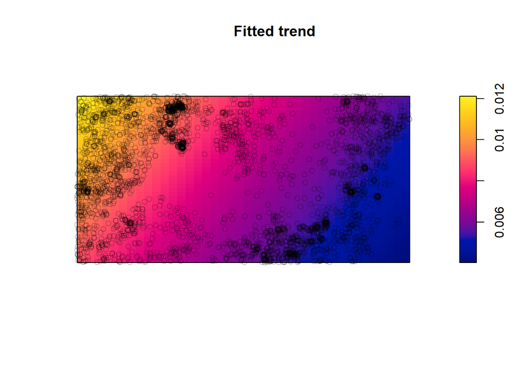

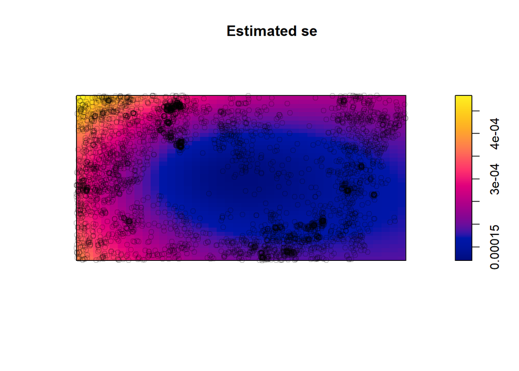

```r
plot(fit, how="image")
```

```r
predict(fit, type="trend")
```

```
## real-valued pixel image
## 128 x 128 pixel array (ny, nx)
## enclosing rectangle: [0, 1000] x [0, 500] metres
```

```r
predict(fit, type="cif", ngrid=256)
```

```
## real-valued pixel image
## 256 x 256 pixel array (ny, nx)
## enclosing rectangle: [0, 1000] x [0, 500] metres
```

```r
coef(fit)
```

```
##   (Intercept)             x             y
## -4.7245290274 -0.0008031288  0.0006496090
```

```r
vcov(fit)
```

```
##               (Intercept)             x             y
## (Intercept)  1.854091e-03 -1.491267e-06 -3.528289e-06
## x           -1.491267e-06  3.437842e-09  1.208410e-14
## y           -3.528289e-06  1.208410e-14  1.338955e-08
```

```r
sqrt(diag(vcov(fit)))
```

```
##  (Intercept)            x            y
## 4.305915e-02 5.863311e-05 1.157132e-04
```

```r
round(vcov(fit, what="corr"), 2)
```

```
##             (Intercept)     x     y
## (Intercept)        1.00 -0.59 -0.71
## x                 -0.59  1.00  0.00
## y                 -0.71  0.00  1.00
```

## 4.3 Model selection

```r
fit <- ppm(bei, ~slope, covariates=list(slope=grad))
fitnull <- update(fit, ~1)
anova(fitnull, fit, test = "Chi")
```

```
## Analysis of Deviance Table
##
## Model 1: ~1   Poisson
## Model 2: ~slope   Poisson
##   Npar Df Deviance  Pr(>Chi)
## 1    1
## 2    2  1   383.11 < 2.2e-16 ***
## ---
## Signif. codes:  0 '***' 0.001 '**' 0.01 '*' 0.05 '.' 0.1 ' ' 1
```

```r
fitprop <- ppm(bei, ~offset(log(slope)), covariates=list(slope=grad))
fitnull <- ppm(bei, ~1)
c(AIC(fitprop),BIC(fitprop))
```

```
## [1] 42494.42 42500.61
```

```r
c(AIC(fitnull),BIC(fitnull))
```

```
## [1] 42763.92 42770.11
```

## 4.4 Simulating the fitted model

A fitted Poisson model can be simulated automatically using the function ${\tt rmh}$.

```r
X <- rmh(fitprop)
```

```
## Extracting model information...Evaluating trend...done.
## Checking arguments..determining simulation windows...Evaluating trend integral...
```

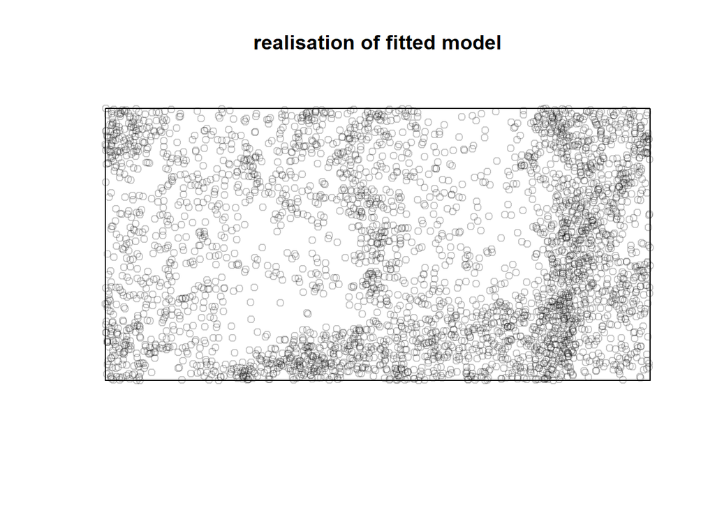

```r
plot(X, main = "realisation of fitted model")
```

# 5 Distance methods for point patterns

Suppose that a point pattern appears to have constant intensity, and we wish to assess whether the pattern is Poisson. The alternative is that the points are dependent (they exhibit interaction). Classical writers suggested a simple trichotomy between independence (the Poisson process), regularity (where points tend to avoid each other), and clustering (where points tend to be close together).

## 5.1 Empty space function $F$

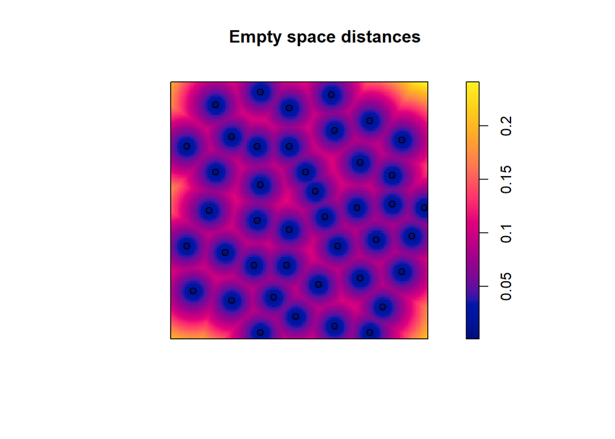

```r
data(cells)
emp <- distmap(cells)
plot(emp, main="Empty space distances")
plot(cells, add=TRUE)
```

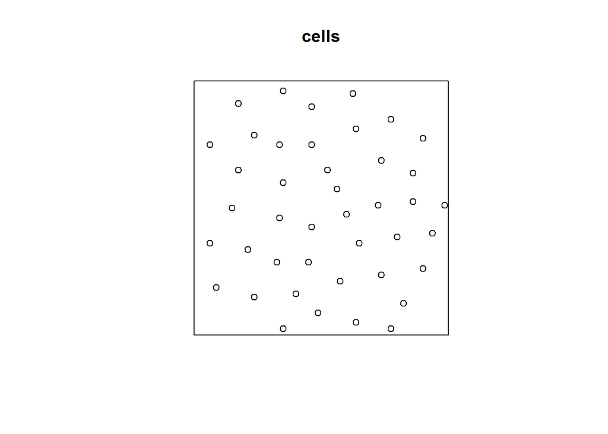

```r
data(cells)
plot(cells)
```

```r
Fc <- Fest(cells)
Fc
```

```
## Function value object (class 'fv')
## for the function r -> F(r)
## .....................................................................
##         Math.label      Description
## r       r               distance argument r
## theo    F[pois](r)      theoretical Poisson F(r)
## cs      hat(F)[cs](r)   Chiu-Stoyan estimate of F(r)
## rs      hat(F)[bord](r) border corrected estimate of F(r)
## km      hat(F)[km](r)   Kaplan-Meier estimate of F(r)
## hazard  hat(h)[km](r)   Kaplan-Meier estimate of hazard function h(r)
## theohaz h[pois](r)      theoretical Poisson hazard h(r)
## .....................................................................
## Default plot formula:  .~r
## where "." stands for 'km', 'rs', 'cs', 'theo'
## Recommended range of argument r: [0, 0.085938]
## Available range of argument r: [0, 0.29688]
```

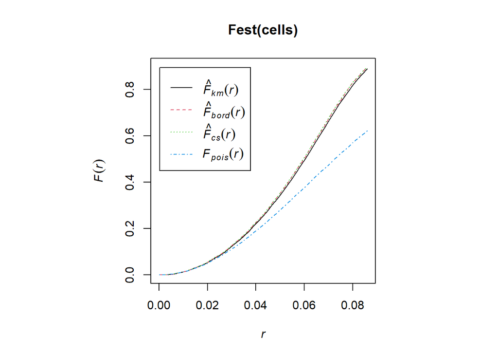

```r
par(pty = "s")
plot(Fest(cells))
```

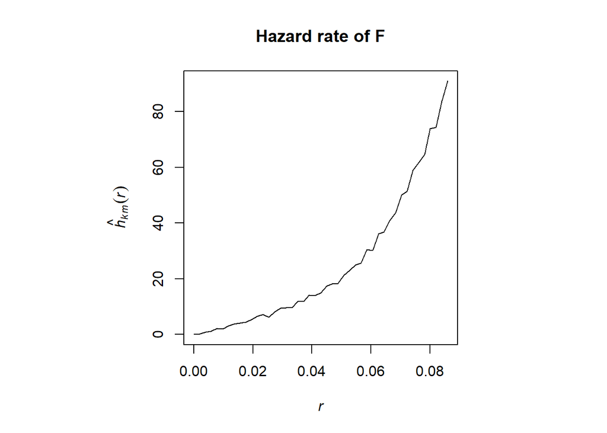

```r
plot(Fest(cells), hazard ~ r, main="Hazard rate of F")
```

## 5.2 Nearest neighbour distances and $G$ function

```r
Gc <- Gest(cells)
Gc
```

```
## Function value object (class 'fv')
## for the function r -> G(r)
## .....................................................................
##         Math.label      Description
## r       r               distance argument r
## theo    G[pois](r)      theoretical Poisson G(r)
## han     hat(G)[han](r)  Hanisch estimate of G(r)
## rs      hat(G)[bord](r) border corrected estimate of G(r)
## km      hat(G)[km](r)   Kaplan-Meier estimate of G(r)
## hazard  hat(h)[km](r)   Kaplan-Meier estimate of hazard function h(r)
## theohaz h[pois](r)      theoretical Poisson hazard function h(r)
## .....................................................................
## Default plot formula:  .~r
## where "." stands for 'km', 'rs', 'han', 'theo'
## Recommended range of argument r: [0, 0.15]
## Available range of argument r: [0, 0.29539]
```

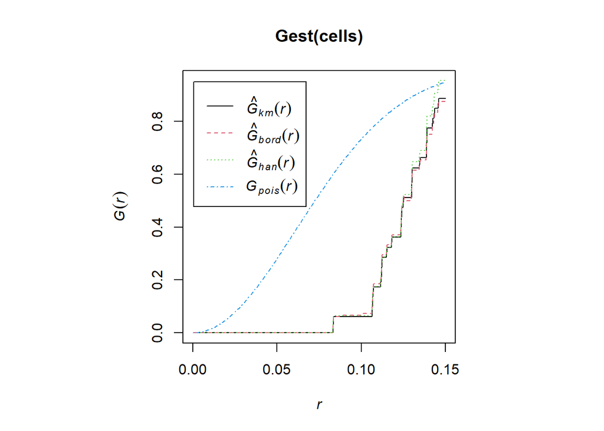

```r
par(pty = "s")
plot(Gest(cells))
```

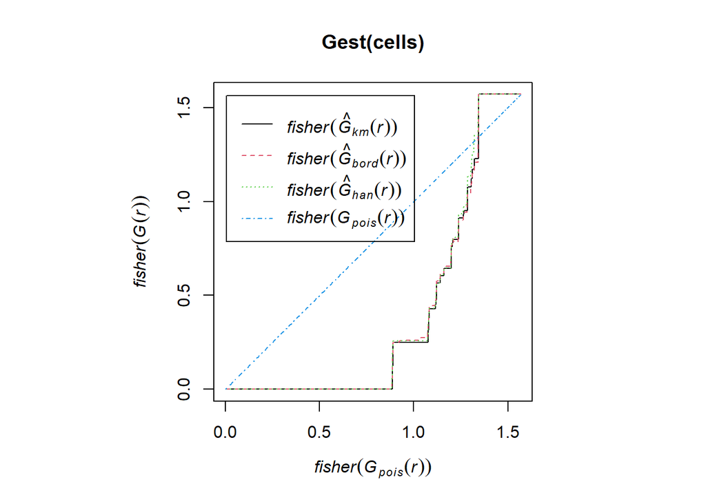

```r
fisher <- function(x) {
 asin(sqrt(x))
}
plot(Gest(cells), fisher(.) ~ fisher(theo))
```

## 5.3 Pairwise distances and the $K$ function

```r
Gc <- Kest(cells)
Gc
```

```
## Function value object (class 'fv')
## for the function r -> K(r)
## ..............................................................
##        Math.label       Description
## r      r                distance argument r
## theo   K[pois](r)       theoretical Poisson K(r)
## border hat(K)[bord](r)  border-corrected estimate of K(r)
## trans  hat(K)[trans](r) translation-corrected estimate of K(r)
## iso    hat(K)[iso](r)   isotropic-corrected estimate of K(r)
## ..............................................................
## Default plot formula:  .~r
## where "." stands for 'iso', 'trans', 'border', 'theo'
## Recommended range of argument r: [0, 0.25]
## Available range of argument r: [0, 0.25]
```

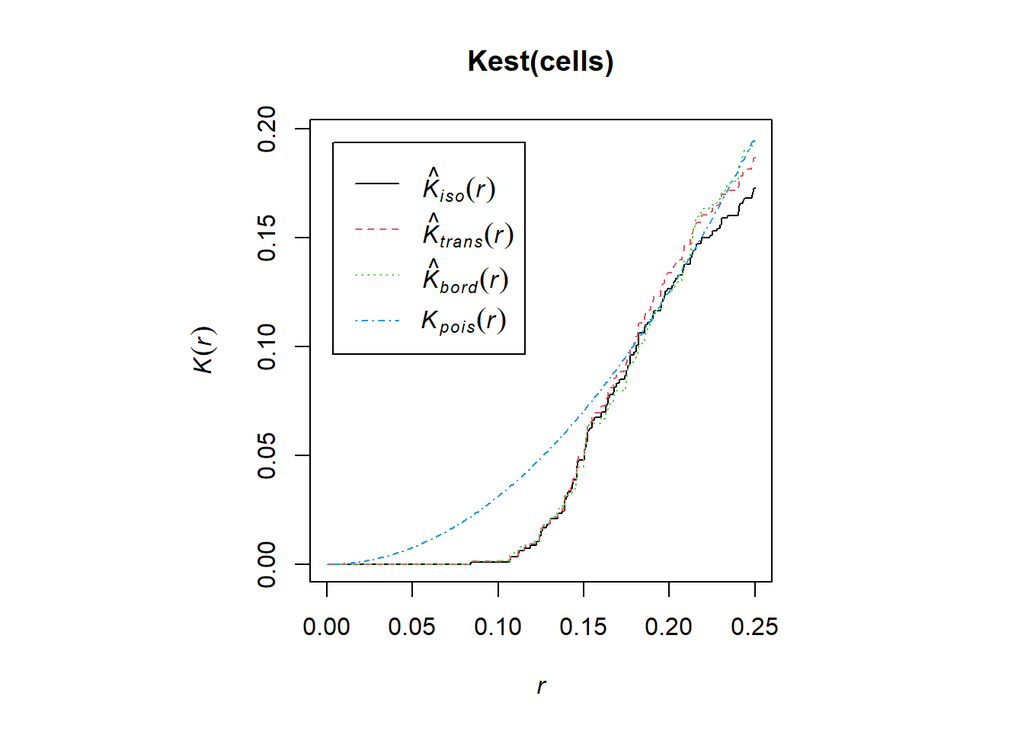

```r
par(pty="s")
plot(Kest(cells))
```

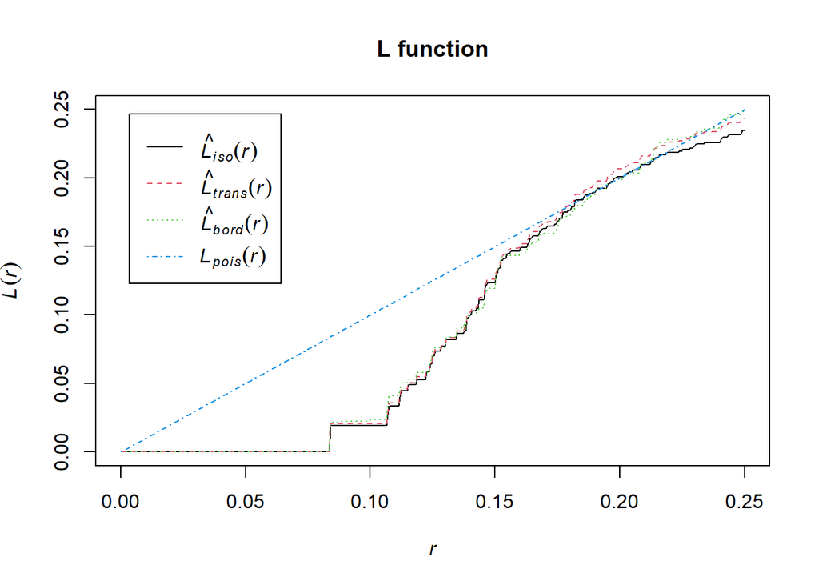

```r
L <- Lest(cells)
plot(L, main="L function")
```

## 5.4 $J$ function

A useful combination of $F$ and $G$ is the $J$ function, $J(r)=\frac{1-G(r)}{1-F(r)}$. For a homogeneous Poisson process, $F=G$, so that $J_{pois}(r)=1$. Value $J(r)>1$ suggest regularity and $J(r)<1$ suggest clustering.

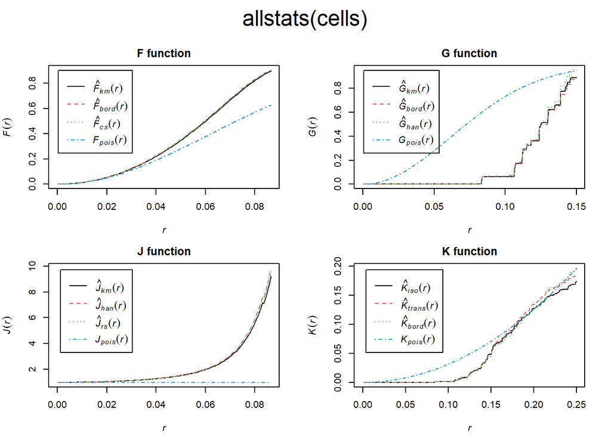

```r
plot(allstats(cells))
```